# Popularity vs. Ability: Exploring the Legitimacy of NBA All-star Voting Process

Jiehwan Yang (양지환)

2016년 9월 14일

# Popularity vs. Ability: Exploring the Legitimacy of NBA All-star Voting Process

## Intro

NBA All-star had repeatedly come under strong criticism from many players, fans, and other important stakeholders alike. There are players like Kobe Bryant, who benefits from his long-standing popularity and reputation and was voted as one of the 2015 NBA All-star players despite of the mediocre season battling with constant injuries. On the other hand, there are players like Damian Lillard and Demarcus Cousins, who do not receive as much attention from media and recognition from fans and did not make it to the 2015 NBA All-star team despite of superb and record-breaking season. Damian Lillard famously tweeted, “I’m definitely going to take it personal. I said I’d be pissed off about it, and I am.”

This controversy around NBA All-star voting stems from its voting process, which selects NBA All-star players solely relying on the Internet and text message ballot from the fans. By utilizing fan voting, the current voting process suffers from couple systematic problems: 1. Only a very small percentage of fan votes is from NBA followers or experts. It automatically leads to uninformed popularity contest rather than basing it on ability.  
2. Celebrities, or anyone who are opinion leaders, also influence the voting by endorsing a player of the same demographic, such as nationality. Due to these reasons, many expressed their dissatisfaction toward and questioned the legitimacy of NBA All-star events in general. Dallas Mavericks owner, Mark Cuban, has claimed that the NBA should get rid of the fan ballot entirely.

With the NBA All-star games always being the the source of contention, it leads to the important question: does popularity trump ability when it comes to the NBA All-star? In other words, are basketball statistics/high performance good predictors to determine if a player will make it into the NBA All-star team? The purpose of this project is to explore the predictability of various basketball statistics on whether a player will make it into the NBA All-star team or not. The results from this project will help better evaluate the strength and the legitimacy of the current voting process and will appeal to various stakeholders of the NBA, ranging from the fans and the players to the NBA commission and the team owners. The next section, methodology, will cover different steps we took to collect, cleanse, and analyze the data and the thought-process behind each step. Then the results of the data mining will be presented and discussed at the end of the paper.

Methodology Data Collection We gathered two different NBA basketball datasets from KDNuggets.com. The first dataset (D1), basketballplayers, is the detailed basketball stats records of every single NBA player in each year from 1950 to 2009. Each observation in D1 is a player in one season, and the attributes include typical basketball stats measurements such as points, rebounds, assists, blocks, etc. The second dataset (D2), ‘basketball_allstar,’ is the similar to the first dataset but the data are limited to only all-star players. Just as it was described in D1, D2’s observations are all-star players in each season, and the attributes characterizing these observations are the same as D1. Data Cleansing and Preprocessing The first step of data preprocessing was merging D1 and D2 together, so that there is one consolidated dataset (D3) with every single NBA player in each year with the additional attribute that indicates if respective player was in the All-star team or not in that given year. This merging was done in the Excel spreadsheet.

The next step involved working with missing data and dirty data. GS (games started) column was removed since all the values were 0 in all observations. We dropped all observations before the year of 1980, since the merger between NBA and ABA happened in 1976, because before that, the way basketball statistics were measured and recorded was different between those two leagues. For the sake of easier data analysis, we dropped everything before 1980. Furthermore, after data exploration, we found that the list of All-star players in 1998 is empty, so we decided to exclude the year 1998 as well.

```
##    playerID year tmID lgID GP minutes points rebounds assists steals blocks turnovers  PF fgAttempted fgMade
## 1 abdulka01 1980  LAL  NBA 80    2976   2095      821     272     59    228       249 244        1457    836
## 2 abernto01 1980  GSW  NBA 10      39      4        8       1      1      0         2   5           3      1
## 3 abernto01 1980  IND  NBA 29     259     59       40      18      6      3         6  29          56     24
## 4 adamsal01 1980  PHO  NBA 75    2054   1115      546     344    106     69       226 226         870    458
## 5 allumda01 1980  DAL  NBA 22     276     59       65      25      5      8        23  51          67     23
## 6 archina01 1980  BOS  NBA 80    2820   1106      176     618     75     18       265 201         766    382
##   ftAttempted ftMade threeAttempted threeMade PostGP PostGS PostMinutes PostPoints PostRebounds PostAssists PostSteals
## 1         552    423              1         0      3      0         134         80           50          12          3
## 2           3      2              0         0      0      0           0          0            0           0          0
## 3          19     11              1         0      0      0           0          0            0           0          0
## 4         259    199              0         0      7      0         218         74           41          26          4
## 5          22     13              1         0      0      0           0          0            0           0          0
## 6         419    342              9         0     17      0         630        266           28         107         13
##   PostBlocks PostTurnovers PostPF PostfgAttempted PostfgMade PostftAttempted PostftMade PostthreeAttempted
## 1          8            11     14              65         30              28         20                  0
## 2          0             0      0               0          0               0          0                  0
## 3          0             0      0               0          0               0          0                  0
## 4          1            19     20              60         27              28         20                  0
## 5          0             0      0               0          0               0          0                  0
## 6          0            50     39             211         95              94         76                  5
##   PostthreeMade Allstar
## 1             0       1
## 2             0       0
## 3             0       0
## 4             0       0
## 5             0       0
## 6             0       1
```

## Classification Analysis

```r
#Select a random sample of our data to use as our training data set.
#Put 50% of the data in training and 50% in test.
ind = sample(1:nrow(dat),floor(nrow(dat)*0.50))
dat_train = dat[ind,]
dat_test = dat[-ind,]
ind = sample(1:nrow(dat),floor(nrow(dat)*0.50))
dat_train = dat[ind,]
dat_test = dat[-ind,]
```

```r
#Load rpart and rpart.plot library in order to perform prediction analysis by using regression tree.
library(rpart)
library(rpart.plot)
```

### Decision Tree

We explored the strength of decision trees by changing the minsplit parameters between 10, 20, and 60. Confusion matrices were utilized to calculate accuracy, precisions, and recalls. It is important to note that we prioritize the predictability of someone making into All-star team than not making into one. Furthermore, we believe that FN is more costly than FP, because most of the dissatisfactions from stakeholders are caused by well-deserved players not making to the team.

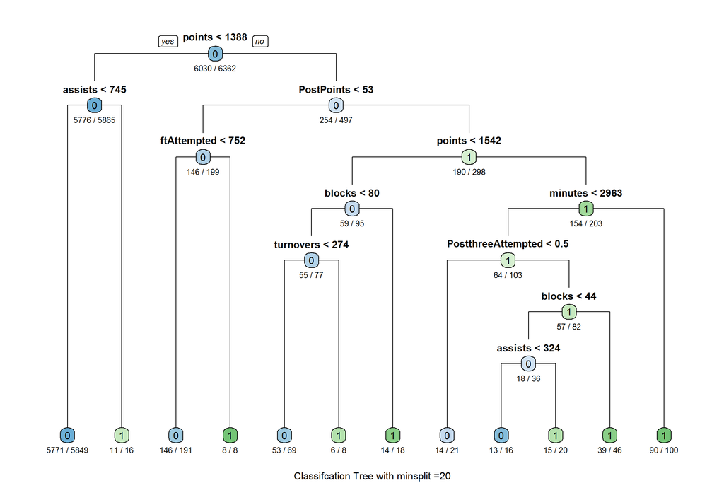

```r
#First, try split the data at minimum split value of 20.
# Minsplit says don't split if you have fewer than 20 observations left in the branch from the training data.
tree_1<-rpart(Allstar ~ GP+ minutes+ points+ rebounds+ assists+ steals+ blocks+ turnovers
              + PF+ fgAttempted+ fgMade+ ftAttempted+ ftMade+ threeAttempted+ threeMade+ PostGP
              + PostMinutes+ PostPoints+ PostRebounds+ PostAssists+ PostSteals+ PostBlocks
              + PostTurnovers+ PostPF+ PostfgAttempted+ PostfgMade+ PostftAttempted+ PostftMade
              + PostthreeAttempted+ PostthreeMade,
              data=dat_train,method = "class",control = rpart.control(minsplit = 20))

#Draw regression tree using rpart.plot
rpart.plot(tree_1,type = 1,extra=2,under=TRUE)
title(sub="Classifcation Tree with minsplit =20 ")
```

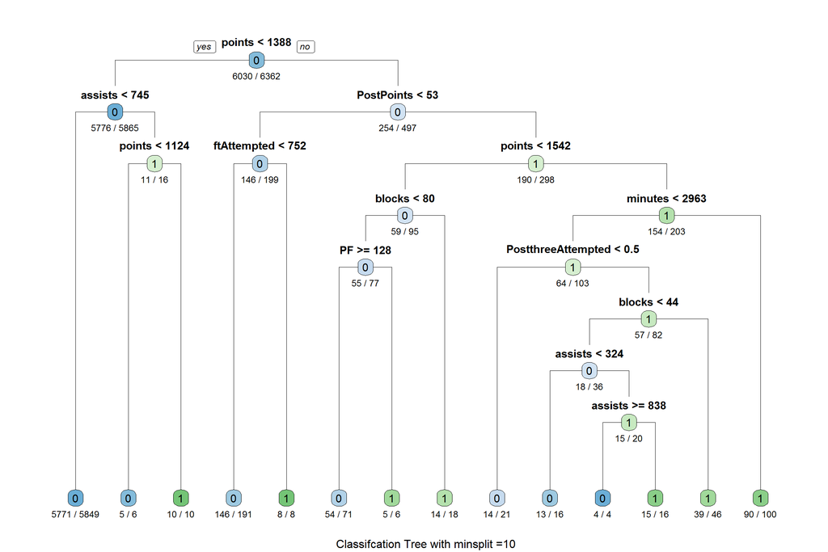

```r
#Try minsplit=10
tree_2<-rpart(Allstar ~ GP+ minutes+ points+ rebounds+ assists+ steals+ blocks+ turnovers
              + PF+ fgAttempted+ fgMade+ ftAttempted+ ftMade+ threeAttempted+ threeMade+ PostGP
              + PostMinutes+ PostPoints+ PostRebounds+ PostAssists+ PostSteals+ PostBlocks
              + PostTurnovers+ PostPF+ PostfgAttempted+ PostfgMade+ PostftAttempted+ PostftMade
              + PostthreeAttempted+ PostthreeMade,
              data=dat_train,method = "class",control = rpart.control(minsplit = 10))
rpart.plot(tree_2,type = 1,extra=2,under=TRUE)
title(sub="Classifcation Tree with minsplit =10 ")
```

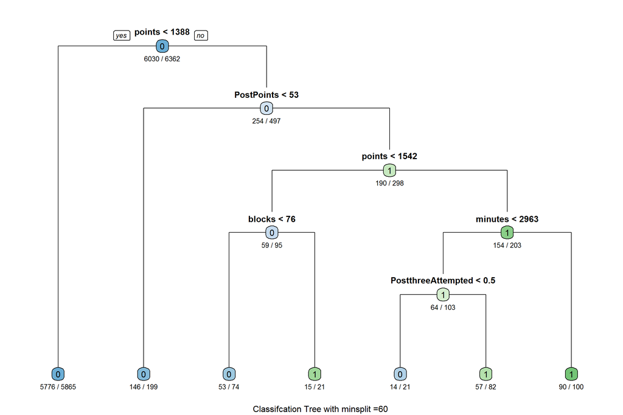

```r
#Try minsplit=60
tree_3<-rpart(Allstar ~ GP+ minutes+ points+ rebounds+ assists+ steals+ blocks+ turnovers
              + PF+ fgAttempted+ fgMade+ ftAttempted+ ftMade+ threeAttempted+ threeMade+ PostGP
              + PostMinutes+ PostPoints+ PostRebounds+ PostAssists+ PostSteals+ PostBlocks
              + PostTurnovers+ PostPF+ PostfgAttempted+ PostfgMade+ PostftAttempted+ PostftMade
              + PostthreeAttempted+ PostthreeMade,
              data=dat_train,method = "class",control = rpart.control(minsplit = 60))
rpart.plot(tree_3,type = 1,extra=2,under=TRUE)
title(sub ="Classifcation Tree with minsplit =60 ")
```

```r
#Predict the classification of each observation in the test data, using the three trees that we built.
dat_test1<- dat_test
dat_test2<- dat_test
dat_test3<- dat_test

dat_test1$pred <- predict(tree_1,dat_test, type="class")
dat_test2$pred <- predict(tree_2,dat_test, type="class")
dat_test3$pred <- predict(tree_3,dat_test, type="class")

#Now let's check out our confusion matrix to see how the tree did.
confusionmatrix1<-table(dat_test1$Allstar,dat_test1$pred,dnn = c("Actual","Predicted"))
confusionmatrix2<-table(dat_test2$Allstar,dat_test2$pred,dnn = c("Actual","Predicted"))
confusionmatrix3<-table(dat_test3$Allstar,dat_test3$pred,dnn = c("Actual","Predicted"))

confusionmatrix1
```

```
##       Predicted
## Actual    0    1
##      0 5963   50
##      1  192  157
```

```r
confusionmatrix2
```

```
##       Predicted
## Actual    0    1
##      0 5966   47
##      1  194  155
```

```r
confusionmatrix3
```

```
##       Predicted
## Actual    0    1
##      0 5962   51
##      1  184  165
```

```r
Accuracy<-(confusionmatrix1[1,1]+confusionmatrix1[2,2])/sum(confusionmatrix1)
Accuracy
```

```
## [1] 0.9619616
```

```r
#precisions
Precision_N<-confusionmatrix1[1,1]/(confusionmatrix1[1,1]+confusionmatrix1[2,1])
Precision_P<-confusionmatrix1[2,2]/(confusionmatrix1[2,2]+confusionmatrix1[1,2])
Precision_N
```

```
## [1] 0.9688058
```

```r
Precision_P
```

```
## [1] 0.7584541
```

```r
#recalls
Recall_N<-confusionmatrix1[1,1]/(confusionmatrix1[1,1]+confusionmatrix1[1,2])
Recall_P<-confusionmatrix1[2,2]/(confusionmatrix1[2,2]+confusionmatrix1[2,1])
Recall_N
```

```
## [1] 0.9916847
```

```r
Recall_P
```

```
## [1] 0.4498567
```